# Data Management

BH Analytics

# Overview

# H2O Overview

> H2O is an open source, in-memory, distributed, fast, and scalable machine learning and predictive analytics platform that allows you to build machine learning models on big data and provides easy productionalization of those models in an enterprise environment.  
> The H2O software is many things, but the primary purpose of H2O is as a distributed (many machines), parallel (many CPUs), in memory (several hundred GBs Xmx) processing engine. H2O uses a distributed key-value store (the “DKV”) that contains pointers to the various objects of the H2O ecosystem. — From the h2o docs

H2O makes paralellism easy in data science easy to implement. H2O is generally fast and efficient, and allows you to not worry about how to make your code fast/efficient.

# Installing H2O

- H2O is easy to install from within R.
- There are a few dependencies (R packages)
  - RCurl
  - bitops
  - rjson
  - statmod
  - tools
- Check out more info here:

http://h2o-release.s3.amazonaws.com/h2o/master/1735/docs-website/Ruser/Rinstall.html

- Here is some R code to install in case you need it in the future:

```r
##### install h2o
## install h2o
# The following two commands remove any previously installed H2O packages for R.
if ("package:h2o" %in% search()) { detach("package:h2o", unload=TRUE) }
if ("h2o" %in% rownames(installed.packages())) { remove.packages("h2o") }

# Next, we download packages that H2O depends on.
pkgs <- c("RCurl","jsonlite")
for (pkg in pkgs) {
  if (! (pkg %in% rownames(installed.packages()))) { install.packages(pkg) }
}

# Now we download, install and initialize the H2O package for R.
install.packages("h2o", type="source", repos="http://h2o-release.s3.amazonaws.com/h2o/rel-zeno/1/R")

# Finally, let's load H2O and start up an H2O cluster
library(h2o)
h2o.init()

# run demo
demo(h2o.glm)
```

# Initiating H2O Session

- We need to initiate an H2O session before we can do any work in it.
- You can shutdown the session remotely (from R) as well.

```r
# Load
library(data.table)
library(h2o)

# Initiate h2o session
h2o.init(ip='localhost',
         port = 54321,
         nthreads = -1,  # use all available threads
         max_mem_size = '2G') # can also specify mem size
```

```
##  Connection successful!
##
## R is connected to the H2O cluster:
##     H2O cluster uptime:         35 minutes 20 seconds
##     H2O cluster timezone:       America/Chicago
##     H2O data parsing timezone:  UTC
##     H2O cluster version:        3.30.1.1
##     H2O cluster version age:    13 days
##     H2O cluster name:           H2O_started_from_R_evancarey_pys370
##     H2O cluster total nodes:    1
##     H2O cluster total memory:   1.31 GB
##     H2O cluster total cores:    8
##     H2O cluster allowed cores:  8
##     H2O cluster healthy:        TRUE
##     H2O Connection ip:          localhost
##     H2O Connection port:        54321
##     H2O Connection proxy:       NA
##     H2O Internal Security:      FALSE
##     H2O API Extensions:         Amazon S3, Algos, AutoML, Core V3, TargetEncoder, Core V4
##     R Version:                  R version 3.6.3 (2020-02-29)
```

```r
# can also specify max memory usage (H2o is bound by memory)
# nthreads = 2 would use 2 threads, -1 is all available
# Shutdown instance using this code
# h2o.shutdown()
# Clean up the session if needed
# This removes everything inside the session
h2o.removeAll()
```

# Checking Cluster Status

- If we have a cluster running, we can ping the cluster for status updates on its health:

```r
# Ask for info on the cluster status
h2o.clusterInfo()
```

```
## R is connected to the H2O cluster:
##     H2O cluster uptime:         35 minutes 21 seconds
##     H2O cluster timezone:       America/Chicago
##     H2O data parsing timezone:  UTC
##     H2O cluster version:        3.30.1.1
##     H2O cluster version age:    13 days
##     H2O cluster name:           H2O_started_from_R_evancarey_pys370
##     H2O cluster total nodes:    1
##     H2O cluster total memory:   1.31 GB
##     H2O cluster total cores:    8
##     H2O cluster allowed cores:  8
##     H2O cluster healthy:        TRUE
##     H2O Connection ip:          localhost
##     H2O Connection port:        54321
##     H2O Connection proxy:       NA
##     H2O Internal Security:      FALSE
##     H2O API Extensions:         Amazon S3, Algos, AutoML, Core V3, TargetEncoder, Core V4
##     R Version:                  R version 3.6.3 (2020-02-29)
```

```r
h2o.clusterIsUp()
```

```
## [1] TRUE
```

```r
# POJO means plain old Java object
```

# Understanding Objects in H2O

Ok great, we have H2O running! Now what?

We should talk about the objects we will be interacting with in H2O a bit first.

- Keys
  - The H2O software has a distributed key-value store (the DKV). This store keeps track of the H2O objects and the pointers to those objects. A key is an entry in this DKV.
- Data frames (also called frames)
  - These objects are the central data containers in H2O. You can think of them like R Dataframes. They are 2 dimensional objects, with a constant data type for each column. Different columns can have different data types.
  - These are distributed objects by default - they can be spread across different clusters of an h2o instance if you have a multi-cluster instance. This is parallel to you for the most part though.
  - These are mutable - they can be changed in place. However, many operations we will explore will return a new dataframe that must be saved. Despite this, some operations will change dataframes in place as well.
  - Dataframes in H2O are parsed into a hexadecimal format (.hex) after ingestion. They must be in this format before we can modify or interact with them much. So after we upload a data file, it will be parsed. You will often see the ‘name’ (pointer) of the object as ******.hex in the documentation for this reason.
  - Each dataframe will have a key associated with it.
- Models
  - We will discuss these more in the next lecture - this is the object type for H2O models we have trained (and can save).
  - Each model will have a key associated with it.
- ModelMetrics
  - We will discuss these more in the next lecture - this is the object type for H2O model performance summaries we have trained.
- Others..
  - There are other objects as well, but we will not focus on them as you don’t need to understand them to use this API. More details can be found here: http://docs.h2o.ai/h2o/latest-stable/h2o-py/docs/intro.html

# The H2O store

You can always check what objects are in the cluster (in the DKV) by calling `h2o.ls()`

```r
# list objects in the DKV
h2o.ls()
```

```
## [1] key
## <0 rows> (or 0-length row.names)
```

As expected, the store is empty since we have not created anything yet. You could clear out all the objects in the store with the remove method if you had objects in the store. This should not be true at initialization.

```r
# remove all objects
h2o.removeAll()
```

```r
# check its empty
h2o.ls()
```

```
## [1] key
## <0 rows> (or 0-length row.names)
```

# A Basic dataframe

Let’s start by creating a basic data frame. Although this seems like a trivial task, we actually often have to create data frames to perform model scoring or other tasks. This also allows us to explore how data frames work.

```r
# create R Datafrmae
df_temp1 <-
  data.frame(id=c(1,2,3),
             name=c('John','Sam','Jane'))

# pass into H2O
df_temp1_hex <-
  as.h2o(df_temp1)
# view the h2o frame
df_temp1_hex
```

```
##   id name
## 1  1 John
## 2  2  Sam
## 3  3 Jane
##
## [3 rows x 2 columns]
```

```r
# the object type is a pointer to the h2o frame
class(df_temp1_hex)
```

```
## [1] "H2OFrame"
```

We can check the DKV to see what has been added. Notice that the name of this object is strange - that is the key seems to be a randomly generated name. We can pull that out by either extracting the element from the data frame returned from the H2O S function comma or we can directly ask for the frame ID if we have the Python pointer object.

```r
# print DKV store
h2o.ls()
```

```
##                   key
## 1 df_temp1_sid_92eb_3
```

```r
# save key store results - this is a dataframe by default.
temp1 = h2o.ls()
# subset to key name
temp1[1,'key']
```

```
## [1] df_temp1_sid_92eb_3
## Levels: df_temp1_sid_92eb_3
```

```r
# use this function to clear the store
h2o.removeAll()
# check it is clear
h2o.ls()
```

```
## [1] key
## <0 rows> (or 0-length row.names)
```

If we would like to give the object a name in the DKV, you can use the `destination_frame=` argument to the function. We will see that this function naming is not consistent across all of the different HTML objects. More on this to come…

```r
# pass into H2O
df_temp1_hex <-
  as.h2o(df_temp1,
         destination_frame = 'df_temp1')
# now see the key with name
h2o.ls()
```

```
##        key
## 1 df_temp1
```

Below I will show you some brief modifications of the data frame. Subsetting and adding new variables is sort of a strange hybrid between R and Python. Although some of the R dataframe API has been adopted, some other functionality is more parallel to the way an R data frame works.

```r
# R style indexing
df_temp1_hex # this returns an h2oFrame
```

```
##   id name
## 1  1 John
## 2  2  Sam
## 3  3 Jane
##
## [3 rows x 2 columns]
```

```r
df_temp1_hex['name'] # this return an h2oFrame
```

```
##   name
## 1 John
## 2  Sam
## 3 Jane
##
## [3 rows x 1 column]
```

```r
df_temp1_hex[1:2,] # this return an h2oFrame
```

```
##   id name
## 1  1 John
## 2  2  Sam
##
## [2 rows x 2 columns]
```

```r
df_temp1_hex[1,'name'] # this returns a vector!
```

```
## [1] John
## Levels: Jane John Sam
```

```r
# create new column
df_temp1_hex['new'] <- 10
df_temp1_hex
```

```
##   id name new
## 1  1 John  10
## 2  2  Sam  10
## 3  3 Jane  10
##
## [3 rows x 3 columns]
```

```r
# these are mutable in place
df_temp1_hex['id_2'] <-
  df_temp1_hex['id'] * 100
df_temp1_hex
```

```
##   id name new id_2
## 1  1 John  10  100
## 2  2  Sam  10  200
## 3  3 Jane  10  300
##
## [3 rows x 4 columns]
```

Another useful function for creating test data frames is the random data frame function all demonstrate below. This function allows you to quickly create a frame with a large number of rows and columns with different data types. This is often used in the H2O documentation and I’ll use it here a little bit as well.

```r
# create a dataframe with random data
df2 <-
  h2o.createFrame(rows=50,
                  cols=5,
                  time_fraction=0.2)
df2
```

```
##             C1        C2        C3  C4     C5
## 1 1.235446e+12  65.76573  35.24591 -88 c4.l74
## 2 1.017241e+12  -9.55783 -20.26286 -85 c4.l81
## 3 1.506099e+12  61.64989  64.22522  91 c4.l17
## 4 1.150872e+12 -34.15115  19.37117   6 c4.l82
## 5 1.099364e+11 -87.89678  46.68708  96 c4.l40
## 6 3.940638e+11  75.49883  81.07118  60   <NA>
##
## [50 rows x 5 columns]
```

We can use the describe function to get information about the dataframe: > Describe returns the dimensions of the frame; names/types/summary statistics for each column; first ten rows of the frame.

```r
# check df data types, describe
h2o.describe(df2)
```

```
##   Label Type Missing Zeros PosInf NegInf           Min          Max         Mean        Sigma Cardinality
## 1    C1 time       0     0      0      0  1.122115e+10 1.549829e+12 7.633743e+11 4.929746e+11          NA
## 2    C2 real       1     0      0      0 -9.362233e+01 9.897447e+01 4.704147e+00 5.777089e+01          NA
## 3    C3 real       1     0      0      0 -9.647584e+01 9.454227e+01 2.542797e+00 6.044269e+01          NA
## 4    C4  int       0     0      0      0 -1.000000e+02 9.900000e+01 2.900000e+00 6.300121e+01          NA
## 5    C5 enum       2     0      0      0  1.000000e+00 9.700000e+01           NA           NA         100
```

```r
# convert to R dataframe
head(as.data.frame(df2))
```

```
##                     C1        C2        C3  C4     C5
## 1 41119-09-22 01:25:09  65.76573  35.24591 -88 c4.l74
## 2 34205-01-30 11:14:11  -9.55783 -20.26286 -85 c4.l81
## 3 49696-05-19 17:37:30  61.64989  64.22522  91 c4.l17
## 4 38439-09-10 18:42:51 -34.15115  19.37117   6 c4.l82
## 5  5453-09-29 20:03:46 -87.89678  46.68708  96 c4.l40
## 6 14457-05-19 21:20:12  75.49883  81.07118  60   <NA>
```

```r
# clear out the DKS
h2o.removeAll()
```

# Data Import: HR Data

- I am going to demonstrate the typical data cleaning and manipulation actions using a small dataset.
- We will import this data directly from the file system
- Following import, you can use `str()`, `summary()`, `describe()`, and `colnames()` to perform the typical data checks.

```r
# Data import directly into h2o from file system
hr.hex <-
  h2o.importFile(path = 'C:/Users/evancarey/Dropbox/Work/Data/hr.csv',
                 destination_frame = 'hr.hex')
# Check out file
str(hr.hex)
```

```
## Class 'H2OFrame' <environment: 0x0000019db2c7e9e8>
##  - attr(*, "op")= chr "Parse"
##  - attr(*, "id")= chr "hr.hex"
##  - attr(*, "eval")= logi FALSE
##  - attr(*, "nrow")= int 105
##  - attr(*, "ncol")= int 9
##  - attr(*, "types")=List of 9
##   ..$ : chr "int"
##   ..$ : chr "enum"
##   ..$ : chr "int"
##   ..$ : chr "time"
##   ..$ : chr "int"
##   ..$ : chr "int"
##   ..$ : chr "int"
##   ..$ : chr "int"
##   ..$ : chr "enum"
##  - attr(*, "data")='data.frame': 10 obs. of  9 variables:
##   ..$ employee_id: num  100 101 102 103 104 105 106 107 108 109
##   ..$ gender     : Factor w/ 2 levels "female","male": 1 2 1 1 1 2 1 1 1 2
##   ..$ age        : num  24 48 28 40 27 43 482 49 43 43
##   ..$ h_date     : num  1.37e+12 1.20e+12 1.23e+12 1.17e+12 1.15e+12 ...
##   ..$ p01        : num  4 2 2 2 1 2 4 NaN 3 4
##   ..$ p02        : num  5 3 2 4 5 NaN 1 5 5 NaN
##   ..$ p03        : num  3 2 2 NaN 5 2 3 1 NaN 1
##   ..$ p04        : num  5 1 2 5 5 3 1 3 5 2
##   ..$ dept       : Factor w/ 5 levels "Admin","Executive",..: 5 5 4 3 1 4 1 4 1 1
```

```r
summary(hr.hex)
```

```
##  employee_id   gender     age              h_date p01             p02             p03             p04            dept
##  Min.   :100   female:72  Min.   : 16.00          Min.   :1.000   Min.   :1.000   Min.   :1.000   Min.   :1.00   Sales    :53
##  1st Qu.:126   male  :33  1st Qu.: 33.00          1st Qu.:2.000   1st Qu.:1.000   1st Qu.:2.000   1st Qu.:2.00   Admin    :22
##  Median :152              Median : 39.00          Median :3.000   Median :3.000   Median :3.000   Median :3.00   Support  :13
##  Mean   :152              Mean   : 80.54          Mean   :3.153   Mean   :2.847   Mean   :2.953   Mean   :3.02   IT       :11
##  3rd Qu.:178              3rd Qu.: 44.00          3rd Qu.:5.000   3rd Qu.:4.000   3rd Qu.:4.000   3rd Qu.:4.50   Executive: 6
##  Max.   :204              Max.   :497.00          Max.   :5.000   Max.   :5.000   Max.   :5.000   Max.   :5.00
##                                                   NA's   :7       NA's   :20      NA's   :19      NA's   :6
```

```r
h2o.describe(hr.hex)
```

```
##         Label Type Missing Zeros PosInf NegInf          Min          Max         Mean        Sigma Cardinality
## 1 employee_id  int       0     0      0      0 1.000000e+02 2.040000e+02 1.520000e+02 3.045488e+01          NA
## 2      gender enum       0    72      0      0 0.000000e+00 1.000000e+00 3.142857e-01 4.664573e-01           2
## 3         age  int       0     0      0      0 1.600000e+01 4.970000e+02 8.054286e+01 1.339103e+02          NA
## 4      h_date time       0     0      0      0 1.114906e+12 1.412122e+12 1.269071e+12 8.294579e+10          NA
## 5         p01  int       7     0      0      0 1.000000e+00 5.000000e+00 3.153061e+00 1.555516e+00          NA
## 6         p02  int      20     0      0      0 1.000000e+00 5.000000e+00 2.847059e+00 1.451648e+00          NA
## 7         p03  int      19     0      0      0 1.000000e+00 5.000000e+00 2.953488e+00 1.371191e+00          NA
## 8         p04  int       6     0      0      0 1.000000e+00 5.000000e+00 3.020202e+00 1.442644e+00          NA
## 9        dept enum       0    22      0      0 0.000000e+00 4.000000e+00           NA           NA           5
```

```r
colnames(hr.hex)
```

```
## [1] "employee_id" "gender"      "age"         "h_date"      "p01"         "p02"         "p03"         "p04"         "dept"
```

```r
# Check the H2O workspace
h2o.ls()
```

```
##      key
## 1 hr.hex
```

```r
# Check the R workspace
ls()
```

```
## [1] "df_temp1"     "df_temp1_hex" "df2"          "hr.hex"       "temp1"
```

# Accessing Vectors (Columns)

- We are often interested in checking out individual columns from a dataframe shortly after import. You can do this with standard R coding syntax here, and the appropriate summary is calculated in H2O and returned.
- Subsetting the data works as expected from base R commands:

```r
# return one column
hr.hex$age
```

```
##   age
## 1  24
## 2  48
## 3  28
## 4  40
## 5  27
## 6  43
##
## [105 rows x 1 column]
```

```r
# Return all columns where age is greater than 150
hr.hex[hr.hex$age > 150,]
```

```
##   employee_id gender age       h_date p01 p02 p03 p04    dept
## 1         106 female 482 1.212278e+12   4   1   3   1   Admin
## 2         112   male 493 1.317427e+12   2   3   1   3 Support
## 3         121 female 483 1.272672e+12   3   3   4   5   Sales
## 4         138 female 489 1.157069e+12   1   1   5   1 Support
## 5         139 female 487 1.264982e+12   2   4   4   1   Admin
## 6         166 female 497 1.349050e+12   1   5   4   5   Sales
##
## [10 rows x 9 columns]
```

- Here are some examples of typical (continuous) numeric summaries:

```r
## Vector summaries
quantile(hr.hex$age)
```

```
##    0.1%      1%     10%     25%   33.3%     50%   66.7%     75%     90%     99%   99.9%
##  16.208  18.080  27.400  33.000  35.000  39.000  43.000  44.000  56.800 497.000 497.000
```

```r
mean(hr.hex$age)
```

```
## [1] 80.54286
```

```r
min(hr.hex$age) # works on h2o objects as well
```

```
## [1] 16
```

```r
max(hr.hex$age)
```

```
## [1] 497
```

```r
## Not all will work
median(hr.hex$age)# doesn't work?
```

[output not shown]

[output cut: 38 more lines]

```
## Error in .h2o.doSafeREST(h2oRestApiVersion = h2oRestApiVersion, urlSuffix = page, :
##
## ERROR MESSAGE:
##
## Column naming requires a string-list, but found a class water.rapids.ast.params.AstNumList
```

```r
# this works!
h2o.median(hr.hex$age)
```

```
## [1] 39
```

- And here are some categorical summaries:

```r
## Freq tables
h2o.unique(hr.hex$gender)
```

```
##       C1
## 1 female
## 2   male
##
## [2 rows x 1 column]
```

```r
h2o.nrow(hr.hex$gender)
```

```
## [1] 105
```

```r
h2o.table(hr.hex$gender)
```

```
##   gender Count
## 1 female    72
## 2   male    33
##
## [2 rows x 2 columns]
```

```r
## create 2-way table
h2o.table(hr.hex[,c('gender','dept')])
```

```
##   gender      dept Counts
## 1 female     Admin     18
## 2 female Executive      4
## 3 female        IT      7
## 4 female     Sales     36
## 5 female   Support      7
## 6   male     Admin      4
##
## [10 rows x 3 columns]
```

```r
## cannot do three way table!
```

# Creating and Deleting Variables

- You can create and delete variables just as we do in Base R commands:

```r
## Create new variable
hr.hex$new <- 1 # vectorized!
hr.hex
```

```
##   employee_id gender age       h_date p01 p02 p03 p04    dept new
## 1         100 female  24 1.372637e+12   4   5   3   5 Support   1
## 2         101   male  48 1.196467e+12   2   3   2   1 Support   1
## 3         102 female  28 1.233446e+12   2   2   2   2   Sales   1
## 4         103 female  40 1.170288e+12   2   4 NaN   5      IT   1
## 5         104 female  27 1.154390e+12   1   5   5   5   Admin   1
## 6         105   male  43 1.157069e+12   2 NaN   2   3   Sales   1
##
## [105 rows x 10 columns]
```

```r
## Delete
hr.hex$new <- NULL
hr.hex
```

```
##   employee_id gender age       h_date p01 p02 p03 p04    dept
## 1         100 female  24 1.372637e+12   4   5   3   5 Support
## 2         101   male  48 1.196467e+12   2   3   2   1 Support
## 3         102 female  28 1.233446e+12   2   2   2   2   Sales
## 4         103 female  40 1.170288e+12   2   4 NaN   5      IT
## 5         104 female  27 1.154390e+12   1   5   5   5   Admin
## 6         105   male  43 1.157069e+12   2 NaN   2   3   Sales
##
## [105 rows x 9 columns]
```

- Type casting works as expected:

```r
## type casting
str(hr.hex)
```

```
## Class 'H2OFrame' <environment: 0x0000019daaed4208>
##  - attr(*, "op")= chr "cols"
##  - attr(*, "eval")= logi TRUE
##  - attr(*, "id")= chr "RTMP_sid_92eb_28"
##  - attr(*, "nrow")= int 105
##  - attr(*, "ncol")= int 9
##  - attr(*, "types")=List of 9
##   ..$ : chr "int"
##   ..$ : chr "enum"
##   ..$ : chr "int"
##   ..$ : chr "time"
##   ..$ : chr "int"
##   ..$ : chr "int"
##   ..$ : chr "int"
##   ..$ : chr "int"
##   ..$ : chr "enum"
##  - attr(*, "data")='data.frame': 10 obs. of  9 variables:
##   ..$ employee_id: num  100 101 102 103 104 105 106 107 108 109
##   ..$ gender     : Factor w/ 2 levels "female","male": 1 2 1 1 1 2 1 1 1 2
##   ..$ age        : num  24 48 28 40 27 43 482 49 43 43
##   ..$ h_date     : num  1.37e+12 1.20e+12 1.23e+12 1.17e+12 1.15e+12 ...
##   ..$ p01        : num  4 2 2 2 1 2 4 NaN 3 4
##   ..$ p02        : num  5 3 2 4 5 NaN 1 5 5 NaN
##   ..$ p03        : num  3 2 2 NaN 5 2 3 1 NaN 1
##   ..$ p04        : num  5 1 2 5 5 3 1 3 5 2
##   ..$ dept       : Factor w/ 5 levels "Admin","Executive",..: 5 5 4 3 1 4 1 4 1 1
```

```r
hr.hex$gender <-
  as.character(hr.hex$gender)
str(hr.hex)
```

```
## Class 'H2OFrame' <environment: 0x0000019da5ffafb8>
##  - attr(*, "op")= chr ":="
##  - attr(*, "eval")= logi TRUE
##  - attr(*, "id")= chr "RTMP_sid_92eb_29"
##  - attr(*, "nrow")= int 105
##  - attr(*, "ncol")= int 9
##  - attr(*, "types")=List of 9
##   ..$ : chr "int"
##   ..$ : chr "string"
##   ..$ : chr "int"
##   ..$ : chr "time"
##   ..$ : chr "int"
##   ..$ : chr "int"
##   ..$ : chr "int"
##   ..$ : chr "int"
##   ..$ : chr "enum"
##  - attr(*, "data")='data.frame': 10 obs. of  9 variables:
##   ..$ employee_id: num  100 101 102 103 104 105 106 107 108 109
##   ..$ gender     : chr  "female" "male" "female" "female" ...
##   ..$ age        : num  24 48 28 40 27 43 482 49 43 43
##   ..$ h_date     : num  1.37e+12 1.20e+12 1.23e+12 1.17e+12 1.15e+12 ...
##   ..$ p01        : num  4 2 2 2 1 2 4 NaN 3 4
##   ..$ p02        : num  5 3 2 4 5 NaN 1 5 5 NaN
##   ..$ p03        : num  3 2 2 NaN 5 2 3 1 NaN 1
##   ..$ p04        : num  5 1 2 5 5 3 1 3 5 2
##   ..$ dept       : Factor w/ 5 levels "Admin","Executive",..: 5 5 4 3 1 4 1 4 1 1
```

- Although you must use as.factor, not just factor:

```r
## Must use as.factor, not factor
hr.hex$gender <-
  as.factor(hr.hex$gender)

## Check for anyFactor present
h2o.anyFactor(hr.hex)
```

```
## [1] TRUE
```

```r
## relevel (set reference group - for modeling)
hr.hex$dept2 <-
  h2o.relevel(hr.hex$dept,'Executive')
str(hr.hex)
```

```
## Class 'H2OFrame' <environment: 0x0000019db50a5dd0>
##  - attr(*, "op")= chr "append"
##  - attr(*, "eval")= logi TRUE
##  - attr(*, "id")= chr "RTMP_sid_92eb_33"
##  - attr(*, "nrow")= int 105
##  - attr(*, "ncol")= int 10
##  - attr(*, "types")=List of 10
##   ..$ : chr "int"
##   ..$ : chr "enum"
##   ..$ : chr "int"
##   ..$ : chr "time"
##   ..$ : chr "int"
##   ..$ : chr "int"
##   ..$ : chr "int"
##   ..$ : chr "int"
##   ..$ : chr "enum"
##   ..$ : chr "enum"
##  - attr(*, "data")='data.frame': 10 obs. of  10 variables:
##   ..$ employee_id: num  100 101 102 103 104 105 106 107 108 109
##   ..$ gender     : Factor w/ 2 levels "female","male": 1 2 1 1 1 2 1 1 1 2
##   ..$ age        : num  24 48 28 40 27 43 482 49 43 43
##   ..$ h_date     : num  1.37e+12 1.20e+12 1.23e+12 1.17e+12 1.15e+12 ...
##   ..$ p01        : num  4 2 2 2 1 2 4 NaN 3 4
##   ..$ p02        : num  5 3 2 4 5 NaN 1 5 5 NaN
##   ..$ p03        : num  3 2 2 NaN 5 2 3 1 NaN 1
##   ..$ p04        : num  5 1 2 5 5 3 1 3 5 2
##   ..$ dept       : Factor w/ 5 levels "Admin","Executive",..: 5 5 4 3 1 4 1 4 1 1
##   ..$ dept2      : Factor w/ 5 levels "Executive","Admin",..: 5 5 4 3 2 4 2 4 2 2
```

```r
hr.hex$dept2 <-NULL
```

# Discretizing Data (from numbers to categories)

- There is a cut function in h2o that works identically to the base cut function.

```r
## Discretize Data
quantile(hr.hex$age)
```

```
##    0.1%      1%     10%     25%   33.3%     50%   66.7%     75%     90%     99%   99.9%
##  16.208  18.080  27.400  33.000  35.000  39.000  43.000  44.000  56.800 497.000 497.000
```

```r
## intentionally insufficient breaks
hr.hex$age_cat <-
  h2o.cut(hr.hex$age,
          breaks = c(16,35,65))
## Data outside breaks set to missing
summary(hr.hex$age_cat)
```

```
##  age_cat
##  (35.0,65.0]:58
##  (16.0,35.0]:36
##  NA         :11
```

```r
# missing excluded from table
h2o.table(hr.hex$age_cat)
```

```
##       age_cat Count
## 1 (16.0,35.0]    36
## 2 (35.0,65.0]    58
##
## [2 rows x 2 columns]
```

```r
# Remove
hr.hex$age_cat <-NULL
```

- You can also use `ifelse()` for more general conditional returns and variable creation:

```r
## Conditional returns to create new variables
hr.hex$age_binary <-
  h2o.ifelse(hr.hex$age > 40, 'Senior','Junior')
hr.hex$age_binary
```

```
##   age_binary
## 1     Junior
## 2     Senior
## 3     Junior
## 4     Junior
## 5     Junior
## 6     Senior
##
## [105 rows x 1 column]
```

```r
hr.hex$age_binary <- NULL
```

- We can visualize distributions with a histogram.
- Plotting functionality is currently limited in H2O, with only a few functions available (mostly in modeling summaries)

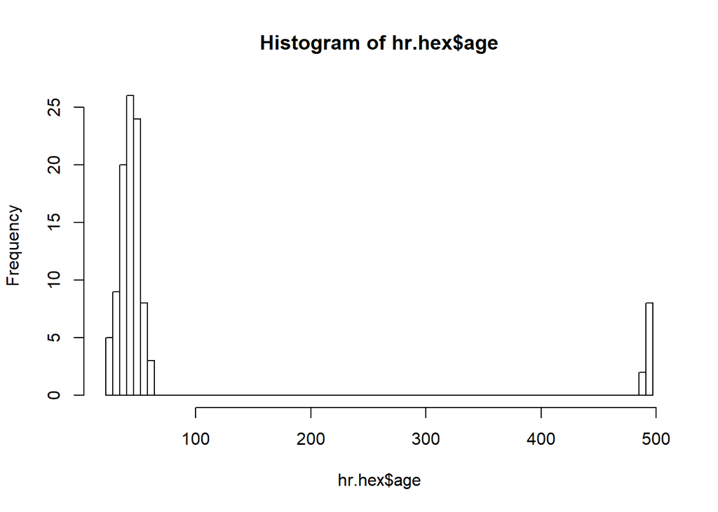

```r
## create a histogram
h2o.hist(hr.hex$age,
         breaks = 80)
```

# String Manipulation in H2O

- String Manipulation in H2O works identically as in base R for the most part (do you see a pattern here yet? :)

```r
## Text Manipulation
## these all return an H2O frame!
class(h2o.tolower(hr.hex$gender))
```

```
## [1] "H2OFrame"
```

```r
h2o.tolower(hr.hex$gender)
```

```
##       C1
## 1 female
## 2   male
## 3 female
## 4 female
## 5 female
## 6   male
##
## [105 rows x 1 column]
```

```r
h2o.toupper(hr.hex$gender)
```

```
##       C1
## 1 FEMALE
## 2   MALE
## 3 FEMALE
## 4 FEMALE
## 5 FEMALE
## 6   MALE
##
## [105 rows x 1 column]
```

```r
h2o.sub(pattern = 'm',
        replacement = '_',
        hr.hex$gender)
```

```
##   gender
## 1 fe_ale
## 2   _ale
## 3 fe_ale
## 4 fe_ale
## 5 fe_ale
## 6   _ale
##
## [105 rows x 1 column]
```

- You can split a string and return an h20 dataframe. We will discuss merging and concatenation later (which will allow you to combine this with the original data…)

```r
## String Split returns an h2o dataframe
h2o.strsplit(split = '',
             hr.hex$gender)
```

```
##   C1 C2 C3 C4   C5   C6
## 1  f  e  m  a    l    e
## 2  m  a  l  e <NA> <NA>
## 3  f  e  m  a    l    e
## 4  f  e  m  a    l    e
## 5  f  e  m  a    l    e
## 6  m  a  l  e <NA> <NA>
##
## [105 rows x 6 columns]
```

- And some more functions you should be familiar with:

```r
## Etc...
h2o.gsub() # global sub, replaces many times
h2o.grep() # search for match
h2o.lstrip() # strip left white space
h2o.rstrip() # strip right white space
```

# Datetime Classes in H2O

- H2O currently does not support non-standard date parsing.
- In this instance, H2O noticed it looked like a date, but failed to correctly autodetect the format.
- We can fix this by reimporting the data and requesting the date columns be character
- We can then type cast it to date, using the correct format statement

```r
## Date time
as.data.table(hr.hex)
```

```
##      employee_id gender age               h_date p01 p02 p03 p04    dept
##   1:         100 female  24 45467-02-16 18:00:00   4   5   3   5 Support
##   2:         101   male  48 39884-07-14 19:00:00   2   3   2   1 Support
##   3:         102 female  28 41056-05-11 19:00:00   2   2   2   2   Sales
##   4:         103 female  40 39054-12-13 18:00:00   2   4  NA   5      IT
##   5:         104 female  27 38551-03-05 18:00:00   1   5   5   5   Admin
##  ---
## 101:         200 female 490 46466-06-18 19:00:00   4   2   5   1   Admin
## 102:         201 female  43 38718-03-10 19:00:00   3  NA   3   1   Sales
## 103:         202 female  31 37803-09-23 19:00:00   5   5   4   2   Sales
## 104:         203 female  39 45384-12-27 18:00:00   5   1   2   4   Sales
## 105:         204   male  35 41803-10-23 19:00:00   2   1   3   3 Support
```

```r
## Notice the dates were incorrect upon import!
## How to fix this...
## We need to reimport the data, and specify the h_Date column to be character
types <- unlist(h2o.getTypes(hr.hex))
types[types == 'time'] <- 'string'
hr.hex2 <-
  h2o.importFile(path = 'C:/Users/evancarey/Dropbox/Work/Data/hr.csv',
                 destination_frame = 'hr.hex2',
                 col.types = types)
## Looks betters
hr.hex$h_date
```

```
##         h_date
## 1 1.372637e+12
## 2 1.196467e+12
## 3 1.233446e+12
## 4 1.170288e+12
## 5 1.154390e+12
## 6 1.157069e+12
##
## [105 rows x 1 column]
```

```r
hr.hex2$h_date
```

```
##      h_date
## 1  7/1/2013
## 2 12/1/2007
## 3  2/1/2009
## 4  2/1/2007
## 5  8/1/2006
## 6  9/1/2006
##
## [105 rows x 1 column]
```

```r
## Now I can convert
hr.hex2$h_date_dt <-
  h2o.as_date(hr.hex2$h_date,
              format = '%m/%d/%Y')
hr.hex2 # looks good
```

```
##   employee_id gender age    h_date p01 p02 p03 p04    dept    h_date_dt
## 1         100 female  24  7/1/2013   4   5   3   5 Support 1.372637e+12
## 2         101   male  48 12/1/2007   2   3   2   1 Support 1.196467e+12
## 3         102 female  28  2/1/2009   2   2   2   2   Sales 1.233446e+12
## 4         103 female  40  2/1/2007   2   4 NaN   5      IT 1.170288e+12
## 5         104 female  27  8/1/2006   1   5   5   5   Admin 1.154390e+12
## 6         105   male  43  9/1/2006   2 NaN   2   3   Sales 1.157069e+12
##
## [105 rows x 10 columns]
```

- There are multiple functions we can use to convert a date into a date component, which is useful for modeling.
- Perhaps we are interested in studying the impact of month, or day of week on the outcome?

```r
## Create various date transformations
## You would need to save these as new variables!
h2o.day(hr.hex2$h_date_dt)
```

```
##   h_date_dt
## 1         1
## 2         1
## 3         1
## 4         1
## 5         1
## 6         1
##
## [105 rows x 1 column]
```

```r
h2o.dayOfWeek(hr.hex2$h_date_dt)
```

```
##   h_date_dt
## 1       Mon
## 2       Sat
## 3       Sun
## 4       Thu
## 5       Tue
## 6       Fri
##
## [105 rows x 1 column]
```

```r
h2o.month(hr.hex2$h_date_dt)
```

```
##   h_date_dt
## 1         7
## 2        12
## 3         2
## 4         2
## 5         8
## 6         9
##
## [105 rows x 1 column]
```

```r
h2o.year(hr.hex2$h_date_dt)
```

```
##   h_date_dt
## 1      2013
## 2      2007
## 3      2009
## 4      2007
## 5      2006
## 6      2006
##
## [105 rows x 1 column]
```

# Sorting the H2O Dataframe

- We use the `h2o.arrange()` function for sorting (similar to dplyr).
- You can only sort by numeric or factors (not strings)

```r
## Sorting - not by string vars!
h2o.arrange(hr.hex2,
            h_date_dt)
```

```
##   employee_id gender age    h_date p01 p02 p03 p04  dept    h_date_dt
## 1         150 female  34  5/1/2005   5 NaN   5   3 Sales 1.114906e+12
## 2         156 female  18  7/1/2005   3   5 NaN   3 Admin 1.120176e+12
## 3         109   male  43  9/1/2005   4 NaN   1   2 Admin 1.125533e+12
## 4         189 female  42 11/1/2005   1 NaN   2   2 Sales 1.130803e+12
## 5         202 female  31 11/1/2005   5   5   4   2 Sales 1.130803e+12
## 6         113   male  41 12/1/2005   5 NaN   3   4 Sales 1.133395e+12
##
## [105 rows x 10 columns]
```

```r
## descending
h2o.arrange(hr.hex2,
            desc(h_date_dt))
```

```
##   employee_id gender age    h_date p01 p02 p03 p04    dept    h_date_dt
## 1         163 female  36 10/1/2014   1   1   4   2   Admin 1.412122e+12
## 2         115 female  26  7/1/2014   5   3   3   5 Support 1.404173e+12
## 3         151   male  45  7/1/2014   2   3   1   3   Sales 1.404173e+12
## 4         200 female 490  7/1/2014   4   2   5   1   Admin 1.404173e+12
## 5         107 female  49  3/1/2014 NaN   5   1   3   Sales 1.393632e+12
## 6         142 female  40  2/1/2014   5   4   5   2   Sales 1.391213e+12
##
## [105 rows x 10 columns]
```

```r
## can do multiple
h2o.arrange(hr.hex2,
            p01,
            desc(h_date_dt))
```

```
##   employee_id gender age   h_date p01 p02 p03 p04  dept    h_date_dt
## 1         107 female  49 3/1/2014 NaN   5   1   3 Sales 1.393632e+12
## 2         119   male  30 4/1/2011 NaN   2   4   5 Admin 1.301616e+12
## 3         130 female  22 4/1/2010 NaN   4   1   5    IT 1.270080e+12
## 4         176   male  32 3/1/2010 NaN   2   2   2 Sales 1.267402e+12
## 5         158 female  39 7/1/2009 NaN   1   1   3 Sales 1.246406e+12
## 6         129 female  27 5/1/2007 NaN   1   3   2    IT 1.177978e+12
##
## [105 rows x 10 columns]
```

# Missing Data in H2O

- Missing data is allowed in H2O dataframes
- You can query the dataframe for missing data elements in ways that should look familiar to you from base R.
- None of these functions are changing the dataframe ‘in-place’. You need to save the results as a new H2O dataframe if you want to access that object.

```r
## count NAs by column
missing_val <-
  h2o.nacnt(hr.hex2)
## add the column names - this should be automatic!
names(missing_val) <-
  colnames(hr.hex2)
missing_val
```

```
## employee_id      gender         age      h_date         p01         p02         p03         p04        dept   h_date_dt
##           0           0           0           0           7          20          19           6           0           0
```

```r
## remove columns with 'frac' percent missing values
indices <-
  h2o.filterNACols(hr.hex2,
                   frac = .01) #(1% here)
hr.hex2[indices]
```

```
##   employee_id gender age    h_date    dept    h_date_dt
## 1         100 female  24  7/1/2013 Support 1.372637e+12
## 2         101   male  48 12/1/2007 Support 1.196467e+12
## 3         102 female  28  2/1/2009   Sales 1.233446e+12
## 4         103 female  40  2/1/2007      IT 1.170288e+12
## 5         104 female  27  8/1/2006   Admin 1.154390e+12
## 6         105   male  43  9/1/2006   Sales 1.157069e+12
##
## [105 rows x 6 columns]
```

```r
## Remove Rows with any missing elements
# Save the result
hr.hex2nomiss <-
  h2o.na_omit(hr.hex2)
h2o.ls()
```

```
##                key
## 1 RTMP_sid_92eb_44
## 2 RTMP_sid_92eb_52
## 3           hr.hex
## 4          hr.hex2
```

```r
h2o.rm('hr.hex2nomiss')
```

- You can also impute missing data using the mean or the median, and optionally do the imputation within group as indicated by factor variables.

```r
# This is an inplace operation!
data.frame(h2o.colnames(hr.hex2),
           h2o.nacnt(hr.hex2))
```

```
##    h2o.colnames.hr.hex2. h2o.nacnt.hr.hex2.
## 1            employee_id                  0
## 2                 gender                  0
## 3                    age                  0
## 4                 h_date                  0
## 5                    p01                  7
## 6                    p02                 20
## 7                    p03                 19
## 8                    p04                  6
## 9                   dept                  0
## 10             h_date_dt                  0
```

```r
h2o.impute(hr.hex2,
           column = 'p01', # optionally impute a single column
           method = 'mean', # can do median here
           by = c('gender')) # Identify a factor
```

```
##   gender mean_p01
## 1 female 3.176471
## 2   male 3.100000
##
## [2 rows x 2 columns]
```

```r
data.frame(h2o.colnames(hr.hex2),
           h2o.nacnt(hr.hex2))
```

```
##    h2o.colnames.hr.hex2. h2o.nacnt.hr.hex2.
## 1            employee_id                  0
## 2                 gender                  0
## 3                    age                  0
## 4                 h_date                  0
## 5                    p01                  0
## 6                    p02                 20
## 7                    p03                 19
## 8                    p04                  6
## 9                   dept                  0
## 10             h_date_dt                  0
```

# Group by functionality in H2O

- You can apply basic functions by group using `h2o.group_by()`, including `mean()`, `count()`, `max()`, `min()`, `mode()`, `sd()`, `sum()`, `var()`

```r
## groupby analysis
h2o.group_by(data = hr.hex2,
             by='gender',
             nrow('age'),
             mean('age'))
```

```
##   gender nrow mean_age
## 1 female   72 79.43056
## 2   male   33 82.96970
##
## [2 rows x 3 columns]
```

# Data Concatenation and Merging

- Concatenation is easy using `h2o.rbind()` and `h2o.cbind()`
- Remember you must save your result!

```r
## Data Concatenation
h2o.cbind()
```

```
## data frame with 0 columns and 0 rows
##
## [0 row x 0 column]
```

```r
?h2o.rbind()
```

- Merges are generally similar as in R.
- However, the full outer join is not supported.

```r
## Merge Data together
hr_dept.hex <-
  h2o.importFile(path = 'C:/Users/evancarey/Dropbox/Work/Data/hr_dept.csv',
                 destination_frame = 'hr_dept.hex',
                 header = T) # had to add this!
## check files
hr_dept.hex
```

```
##   department building
## 1      Sales        A
## 2         IT        B
## 3  Executive        A
## 4      Admin        A
## 5      Other        B
##
## [5 rows x 2 columns]
```

```r
hr.hex2
```

```
##   employee_id gender age    h_date p01 p02 p03 p04    dept    h_date_dt
## 1         100 female  24  7/1/2013   4   5   3   5 Support 1.372637e+12
## 2         101   male  48 12/1/2007   2   3   2   1 Support 1.196467e+12
## 3         102 female  28  2/1/2009   2   2   2   2   Sales 1.233446e+12
## 4         103 female  40  2/1/2007   2   4 NaN   5      IT 1.170288e+12
## 5         104 female  27  8/1/2006   1   5   5   5   Admin 1.154390e+12
## 6         105   male  43  9/1/2006   2 NaN   2   3   Sales 1.157069e+12
##
## [105 rows x 10 columns]
```

```r
# Check merge
h2o.unique(as.factor(hr_dept.hex$department))
```

```
##          C1
## 1     Admin
## 2 Executive
## 3        IT
## 4     Other
## 5     Sales
##
## [5 rows x 1 column]
```

```r
h2o.unique(as.factor(hr.hex2$dept))
```

```
##          C1
## 1     Admin
## 2 Executive
## 3        IT
## 4     Sales
## 5   Support
##
## [5 rows x 1 column]
```

```r
str(hr.hex2)
```

```
## Class 'H2OFrame' <environment: 0x0000019d9f1ddc28>
##  - attr(*, "op")= chr "append"
##  - attr(*, "eval")= logi TRUE
##  - attr(*, "id")= chr "RTMP_sid_92eb_52"
##  - attr(*, "types")=List of 10
##   ..$ : chr "int"
##   ..$ : chr "enum"
##   ..$ : chr "int"
##   ..$ : chr "string"
##   ..$ : chr "real"
##   ..$ : chr "int"
##   ..$ : chr "int"
##   ..$ : chr "int"
##   ..$ : chr "enum"
##   ..$ : chr "int"
##  - attr(*, "nrow")= int 105
##  - attr(*, "ncol")= int 10
##  - attr(*, "data")='data.frame': 10 obs. of  10 variables:
##   ..$ employee_id: num  100 101 102 103 104 105 106 107 108 109
##   ..$ gender     : Factor w/ 2 levels "female","male": 1 2 1 1 1 2 1 1 1 2
##   ..$ age        : num  24 48 28 40 27 43 482 49 43 43
##   ..$ h_date     : chr  "7/1/2013" "12/1/2007" "2/1/2009" "2/1/2007" ...
##   ..$ p01        : num  4 2 2 2 1 ...
##   ..$ p02        : num  5 3 2 4 5 NaN 1 5 5 NaN
##   ..$ p03        : num  3 2 2 NaN 5 2 3 1 NaN 1
##   ..$ p04        : num  5 1 2 5 5 3 1 3 5 2
##   ..$ dept       : Factor w/ 5 levels "Admin","Executive",..: 5 5 4 3 1 4 1 4 1 1
##   ..$ h_date_dt  : num  1.37e+12 1.20e+12 1.23e+12 1.17e+12 1.15e+12 ...
```

```r
str(hr_dept.hex)
```

```
## Class 'H2OFrame' <environment: 0x0000019db31fccb0>
##  - attr(*, "op")= chr "Parse"
##  - attr(*, "id")= chr "hr_dept.hex"
##  - attr(*, "eval")= logi FALSE
##  - attr(*, "nrow")= int 5
##  - attr(*, "ncol")= int 2
##  - attr(*, "types")=List of 2
##   ..$ : chr "string"
##   ..$ : chr "enum"
##  - attr(*, "data")='data.frame': 5 obs. of  2 variables:
##   ..$ department: chr  "Sales" "IT" "Executive" "Admin" ...
##   ..$ building  : Factor w/ 2 levels "A","B": 1 2 1 1 2
```

```r
# make both factors
hr_dept.hex$department <-
  as.factor(hr_dept.hex$department)
hr.hex2$dept <-
  as.factor(hr.hex2$dept)

# Full merge not supported
# Left merge
hr_merged.hex <-
  h2o.merge(x = hr.hex2,
            y = hr_dept.hex,
            by.x = 'dept',
            by.y = 'department',
            all.x=T)
hr_merged.hex
```

```
##      dept employee_id gender age    h_date p01 p02 p03 p04    h_date_dt building
## 1 Support         100 female  24  7/1/2013   4   5   3   5 1.372637e+12     <NA>
## 2 Support         101   male  48 12/1/2007   2   3   2   1 1.196467e+12     <NA>
## 3 Support         112   male 493 10/1/2011   2   3   1   3 1.317427e+12     <NA>
## 4 Support         115 female  26  7/1/2014   5   3   3   5 1.404173e+12     <NA>
## 5 Support         120   male  44  4/1/2006   5   4   1   2 1.143850e+12     <NA>
## 6 Support         123 female  37  7/1/2008   5   3 NaN   5 1.214870e+12     <NA>
##
## [105 rows x 11 columns]
```

```r
# Right merge
hr_merged.hex <-
  h2o.merge(x = hr.hex2,
            y = hr_dept.hex,
            by.x = 'dept',
            by.y = 'department',
            all.y=T)
hr_merged.hex
```

```
##   department employee_id gender age    h_date p01 p02 p03 p04    h_date_dt building
## 1      Other         NaN   <NA> NaN      <NA> NaN NaN NaN NaN          NaN        B
## 2      Admin         104 female  27  8/1/2006   1   5   5   5 1.154390e+12        A
## 3      Admin         106 female 482  6/1/2008   4   1   3   1 1.212278e+12        A
## 4      Admin         108 female  43 11/1/2013   3   5 NaN   5 1.383264e+12        A
## 5      Admin         109   male  43  9/1/2005   4 NaN   1   2 1.125533e+12        A
## 6      Admin         111 female  44  5/1/2007   2 NaN   1   4 1.177978e+12        A
##
## [93 rows x 11 columns]
```

```r
# Inner merge
hr_merged.hex <-
  h2o.merge(x = hr.hex2,
            y = hr_dept.hex,
            by.x = 'dept',
            by.y = 'department',
            all=F)
hr_merged.hex
```

```
##    dept employee_id gender age    h_date p01 p02 p03 p04    h_date_dt building
## 1 Admin         104 female  27  8/1/2006 1.0   5   5   5 1.154390e+12        A
## 2 Admin         106 female 482  6/1/2008 4.0   1   3   1 1.212278e+12        A
## 3 Admin         108 female  43 11/1/2013 3.0   5 NaN   5 1.383264e+12        A
## 4 Admin         109   male  43  9/1/2005 4.0 NaN   1   2 1.125533e+12        A
## 5 Admin         111 female  44  5/1/2007 2.0 NaN   1   4 1.177978e+12        A
## 6 Admin         119   male  30  4/1/2011 3.1   2   4   5 1.301616e+12        A
##
## [92 rows x 11 columns]
```

# What We Covered

- Creating and deleting variables
- Discretizing
- String manipulation
- Datetimes
- Missing Data
- Sorting
- Group by functionality
- Merging/Concatenation